# Orientation: 75% POST1 FILTERED L2

## Data analysis

We load the data and remove the cases with NA values.

We have 122 subjects for a total of 1952 observations.

After removal of subjects with POST1 and POST2 <75% and entries with missing data due to wrong answers, we have 89 subjects and 1144 observations left.

We consider the following independent variables: - `LEAYRS` a numerical variable with values ranging from 1 to 16. Learning in years. - `LEA` a percentage scaled to lay between 0 and 10. It indicates the novelty of target construction, measured by subtracting pretest score from posttestscore (POST1-PRE). This value indicates the previous knowledge of construction. - `AMSP` a numerical variable with values ranging from 1 to 5. - `HRSD` a numerical variable with values ranging from 0 to 11.5. L2 use in hours per day.

We rescaled some of these variables to be on similar scales. We treat these as fixed factors under study. In addition we have the random factors described earlier. The same modelling set up applies here.

Our base model is the following `lmm <- lmer(log(Time) ~ type + LEAYRS + LEA + AMSP + HRSD + (1 | List:Name) + (1 | List:type:Order), data = DLM)`

```r
lmm <- lmer(log(Time) ~  type + LEAYRS + LEA + AMSP + HRSD + (1 | List:Name) + (1 | List:type:Order), data = DLM, REML=FALSE)
#summary(lmm)
```

We use a manual, step-forward procedure with likelihood ratio test to see which of the fixed effects are significant.

```r
lmm.0 <- lmer(log(Time) ~  (1 | List:Name) + (1 | List:type:Order), data = DLM)

lmm.1 <- update(lmm.0, .~. + type)
anova(lmm.0,lmm.1)
```

```
## refitting model(s) with ML (instead of REML)
```

```
## Data: DLM
## Models:
## lmm.0: log(Time) ~ (1 | List:Name) + (1 | List:type:Order)
## lmm.1: log(Time) ~ (1 | List:Name) + (1 | List:type:Order) + type
##       Df  AIC  BIC logLik deviance Chisq Chi Df Pr(>Chisq)
## lmm.0  4 1428 1449   -710     1420
## lmm.1  5 1430 1456   -710     1420  0.01      1       0.94
```

```r
lmm.2 <- update(lmm.0, .~.+LEAYRS)
anova(lmm.0,lmm.2)
```

```
## refitting model(s) with ML (instead of REML)
```

```
## Data: DLM
## Models:
## lmm.0: log(Time) ~ (1 | List:Name) + (1 | List:type:Order)
## lmm.2: log(Time) ~ (1 | List:Name) + (1 | List:type:Order) + LEAYRS
##       Df  AIC  BIC logLik deviance Chisq Chi Df Pr(>Chisq)
## lmm.0  4 1428 1449   -710     1420
## lmm.2  5 1422 1447   -706     1412  8.22      1     0.0041 **
## ---
## Signif. codes:  0 '***' 0.001 '**' 0.01 '*' 0.05 '.' 0.1 ' ' 1
```

```r
lmm.3 <- update(lmm.0, .~. + LEA)
anova(lmm.0,lmm.3)
```

```
## refitting model(s) with ML (instead of REML)
```

```
## Data: DLM
## Models:
## lmm.0: log(Time) ~ (1 | List:Name) + (1 | List:type:Order)
## lmm.3: log(Time) ~ (1 | List:Name) + (1 | List:type:Order) + LEA
##       Df  AIC  BIC logLik deviance Chisq Chi Df Pr(>Chisq)
## lmm.0  4 1428 1449   -710     1420
## lmm.3  5 1428 1453   -709     1418  2.89      1      0.089 .
## ---
## Signif. codes:  0 '***' 0.001 '**' 0.01 '*' 0.05 '.' 0.1 ' ' 1
```

```r
lmm.4 <- update(lmm.0, .~. + AMSP)
anova(lmm.0,lmm.4)
```

```
## refitting model(s) with ML (instead of REML)
```

```
## Data: DLM
## Models:
## lmm.0: log(Time) ~ (1 | List:Name) + (1 | List:type:Order)
## lmm.4: log(Time) ~ (1 | List:Name) + (1 | List:type:Order) + AMSP
##       Df  AIC  BIC logLik deviance Chisq Chi Df Pr(>Chisq)
## lmm.0  4 1428 1449   -710     1420
## lmm.4  5 1430 1455   -710     1420  0.53      1       0.47
```

```r
lmm.5 <- update(lmm.0, .~. + HRSD)
anova(lmm.0,lmm.5)
```

```
## refitting model(s) with ML (instead of REML)
```

```
## Data: DLM
## Models:
## lmm.0: log(Time) ~ (1 | List:Name) + (1 | List:type:Order)
## lmm.5: log(Time) ~ (1 | List:Name) + (1 | List:type:Order) + HRSD
##       Df  AIC  BIC logLik deviance Chisq Chi Df Pr(>Chisq)
## lmm.0  4 1428 1449   -710     1420
## lmm.5  5 1430 1455   -710     1420  0.67      1       0.41
```

An automatic, step-backward procedure from the package lmerTest starting from a model that includes all second order fixed factor intereactions lead to a similar conclusion: the factors `type`, `LEA`, `AMSP`, `HRSD` are not significant while `LEAYRS` is the only significant factor. An ANOVA, shown below, confirms this analysis with `LEAYRS` as the only significant factor.

```r
require(lmerTest)
lmm.6 <- lmer(log(Time) ~ (type + LEAYRS + LEA + AMSP + HRSD)^2 + (1 | List:Name) + (1 | List:type:Order), data = DLM)
ft<-step(lmm.6)
ft
```

```
##
## Random effects:
##                 Chi.sq Chi.DF elim.num p.value
## List:Name       195.69      1     kept < 1e-07
## List:type:Order  83.51      1     kept < 1e-07
##
## Fixed effects:
##             Sum Sq Mean Sq NumDF   DenDF F.value elim.num Pr(>F)
## LEAYRS:LEA  0.0001  0.0001     1   75.38  0.0007        1 0.9788
## type:HRSD   0.0006  0.0006     1 1041.39  0.0037        2 0.9513
## LEAYRS:AMSP 0.0016  0.0016     1   76.35  0.0097        3 0.9217
## type:LEA    0.0027  0.0027     1 1036.68  0.0159        4 0.8995
## LEA:HRSD    0.0029  0.0029     1   82.33  0.0171        5 0.8962
## LEA:AMSP    0.0389  0.0389     1   79.05  0.2321        6 0.6313
## LEAYRS:HRSD 0.0951  0.0951     1   79.83  0.5670        7 0.4537
## AMSP:HRSD   0.0436  0.0436     1   82.18  0.2601        8 0.6114
## type:AMSP   0.0998  0.0998     1 1034.72  0.5953        9 0.4405
## AMSP        0.0823  0.0823     1   81.73  0.4908       10 0.4855
## LEA         0.2583  0.2583     1   82.45  1.5408       11 0.2180
## type:LEAYRS 0.2923  0.2923     1 1033.91  1.7441       12 0.1869
## type        0.0011  0.0011     1   30.07  0.0064       13 0.9367
## HRSD        0.4978  0.4978     1   87.95  2.9676       14 0.0885
## LEAYRS      1.4159  1.4159     1   84.28  8.4413     kept 0.0047
##
## Least squares means:
##      Estimate Standard Error DF t-value Lower CI Upper CI p-value
##
##  Differences of LSMEANS:
##      Estimate Standard Error DF t-value Lower CI Upper CI p-value
##
## Final model:
## lme4::lmer(formula = log(Time) ~ LEAYRS + (1 | List:Name) + (1 |
##     List:type:Order), data = DLM, REML = reml.lmerTest.private,
##     contrasts = l.lmerTest.private.contrast, devFunOnly = devFunOnly.lmerTest.private)
```

```r
summary(ft$model)
```

```
## Linear mixed model fit by REML t-tests use Satterthwaite
##   approximations to degrees of freedom [lmerMod]
## Formula:
## log(Time) ~ LEAYRS + (1 | List:Name) + (1 | List:type:Order)
##    Data: DLM
##
## REML criterion at convergence: 1423.7
##
## Scaled residuals:
##     Min      1Q  Median      3Q     Max
## -3.0444 -0.6870 -0.0964  0.5834  2.8406
##
## Random effects:
##  Groups          Name        Variance Std.Dev.
##  List:Name       (Intercept) 0.0656   0.256
##  List:type:Order (Intercept) 0.0217   0.147
##  Residual                    0.1677   0.410
## Number of obs: 1144, groups:  List:Name, 89; List:type:Order, 32
##
## Fixed effects:
##             Estimate Std. Error       df t value Pr(>|t|)
## (Intercept)   6.9510     0.0574 104.4000  121.15   <2e-16 ***
## LEAYRS       -0.0382     0.0131  84.3000   -2.91   0.0047 **
## ---
## Signif. codes:  0 '***' 0.001 '**' 0.01 '*' 0.05 '.' 0.1 ' ' 1
##
## Correlation of Fixed Effects:
##        (Intr)
## LEAYRS -0.718
```

```r
lmm<-ft$model
```

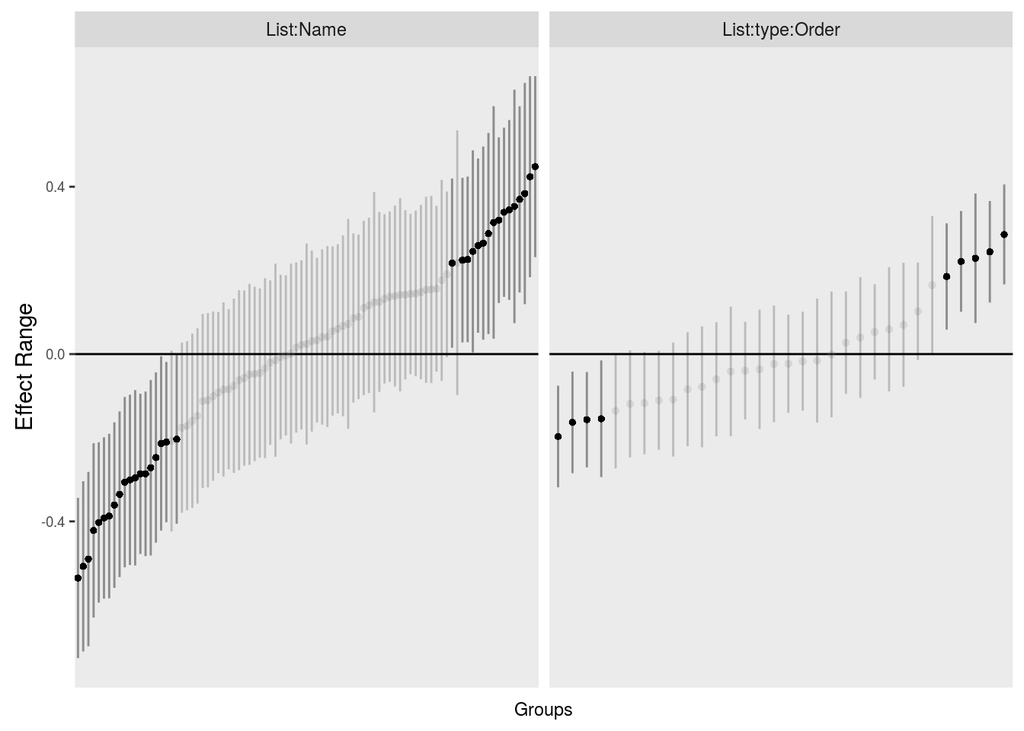

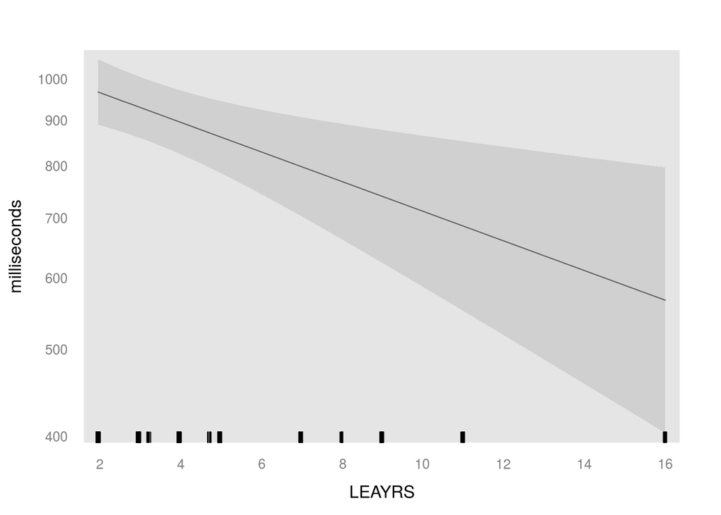

## Diagnostic plots

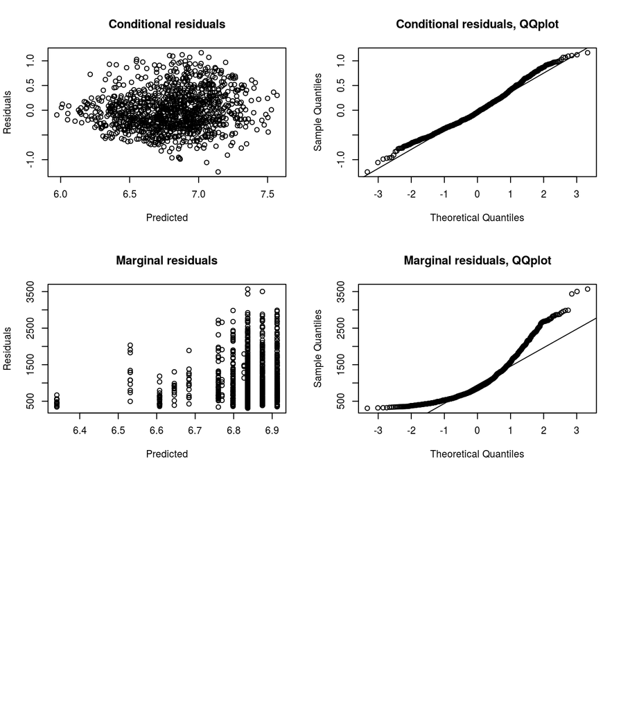

```r
par(mfrow=c(3,2))
# plot(lm4,which=1:4)

plot(fitted(lmm, type = "response"), residuals(lmm, type = "response"),
     main = "Conditional residuals", xlab = "Predicted", ylab = "Residuals")

res <- residuals(lmm, type = "response")
qqnorm(res, main = "Conditional residuals, QQplot")
qqline(res)

#lm.0 <- lm(log(Time) ~ ( type + LEAYRS + LEA + AMSP + HRSD ), data = DLM)
lm.0 <- lm(log(Time) ~ (  LEAYRS ), data = DLM)
x <- model.matrix(lm.0)
pred <- x %*% fixef(lmm)
res <- DLM$Time - pred
plot(pred, res, main = "Marginal residuals", xlab = "Predicted", ylab = "Residuals")
qqnorm(res, main = "Marginal residuals, QQplot")
qqline(res)
```

The joint qqplot looks normal. The marginal looks less nice.

## Anova Table with Satterwhite

```r
require(lmerTest)
lmm <- lmer(log(Time) ~  type + LEAYRS + LEA + AMSP + HRSD + (1 | List:Name) + (1 | List:type:Order), data = DLM, REML=FALSE)
anova(lmm)
```

```
## Analysis of Variance Table of type III  with  Satterthwaite
## approximation for degrees of freedom
##        Sum Sq Mean Sq NumDF DenDF F.value Pr(>F)
## type    0.001   0.001     1  31.9    0.01 0.9324
## LEAYRS  1.775   1.775     1  85.5   10.57 0.0016 **
## LEA     0.273   0.273     1  86.1    1.63 0.2055
## AMSP    0.087   0.087     1  86.4    0.52 0.4726
## HRSD    0.197   0.197     1  92.3    1.17 0.2817
## ---
## Signif. codes:  0 '***' 0.001 '**' 0.01 '*' 0.05 '.' 0.1 ' ' 1
```

```r
summary(lmm)
```

```
## Linear mixed model fit by maximum likelihood t-tests use
##   Satterthwaite approximations to degrees of freedom [lmerMod]
## Formula:
## log(Time) ~ type + LEAYRS + LEA + AMSP + HRSD + (1 | List:Name) +
##     (1 | List:type:Order)
##    Data: DLM
##
##      AIC      BIC   logLik deviance df.resid
##   1425.1   1470.5   -703.6   1407.1     1135
##
## Scaled residuals:
##    Min     1Q Median     3Q    Max
## -3.090 -0.680 -0.102  0.590  2.817
##
## Random effects:
##  Groups          Name        Variance Std.Dev.
##  List:Name       (Intercept) 0.0595   0.244
##  List:type:Order (Intercept) 0.0212   0.145
##  Residual                    0.1678   0.410
## Number of obs: 1144, groups:  List:Name, 89; List:type:Order, 32
##
## Fixed effects:
##              Estimate Std. Error       df t value Pr(>|t|)
## (Intercept)   6.87740    0.17561 93.20000   39.16   <2e-16 ***
## typeMISMATCH -0.00491    0.05738 31.90000   -0.09   0.9324
## LEAYRS       -0.04310    0.01325 85.50000   -3.25   0.0016 **
## LEA          -0.01885    0.01478 86.10000   -1.28   0.2055
## AMSP          0.03145    0.04359 86.40000    0.72   0.4726
## HRSD          0.01621    0.01497 92.30000    1.08   0.2817
## ---
## Signif. codes:  0 '***' 0.001 '**' 0.01 '*' 0.05 '.' 0.1 ' ' 1
##
## Correlation of Fixed Effects:
##             (Intr) tMISMA LEAYRS LEA    AMSP
## typMISMATCH -0.164
## LEAYRS      -0.086  0.001
## LEA         -0.277 -0.004 -0.126
## AMSP        -0.895  0.005 -0.086  0.014
## HRSD         0.239 -0.007 -0.231  0.178 -0.391
```